# Shark Attacks are Rising

Nadiya Klymenko, Trevor Smith

Introduction: In this report, we will be analyzing Shark Attack cases from 1900-2017. The original dataset includes information about if the shark attack was fatal, which activity the person was doing when they got attacked, as well as, which country the attack was in. In this report, we primarily focus on where the attack occurred, as well as, which activity was being demonstrated when the person was attacked. The purpose for this report is to give the public a better understanding of the activities that they should be careful of when visiting other countries, as well as, in their own home. A shark attack is dangerous and could potentially end someone’s life. Being aware of what to be careful of with shark attacks is the first step to being safe. According to this article https://www.cbsnews.com/news/great-white-sharks-coming-closer-to-shore-people/ sharks are starting to come closer to the shore. Knowing this, we need to knowledgable about which actvities will be more dangerous.

1. Getting Started These are the libraries that we will be using for this project today:

```r
library(tidyverse)
```

```r
library(ggplot2)
library(dplyr)
```

We, first, download the dataset that we are planning to analyze. You can find this dataset at https://www.kaggle.com/teajay/global-shark-attacks/version/7 For the focus of this report, we are going to remove a lot of the original dataset that we find unnecessary.

Now, below is our updated dataset. We decided to split the case number into separate columns in order to extract the year and month to be used for further analysis. We also decided to keep the country the attack was in, as well as, the activity the attack was in. At first thought, we split the data based on the actual date parameter. But, since there was a lot of variation amongst that column, we ended up losing a lot of data points. So, to prevent loss of data, we broke up the information from the Case number tab using the separate function. You can read about the separate function here: https://www.rdocumentation.org/packages/tidyr/versions/0.8.3/topics/separate, if interested. We also decided to limit our data starting from 1900-2017, this gives us relevant information and is a large enough range that we could potentially see a trend later down the line. This dataset will be what we use for the report.

```
##   Year Month      Country
## 2 1900    00        ITALY
## 3 1901    12    AUSTRALIA
## 4 1901    10  PHILIPPINES
## 5 1901    09       CYPRUS
## 6 1901    07 SOUTH AFRICA
## 7 1901    07        ITALY
##                                                      Activity
## 2                                                     Fishing
## 3                                                     Bathing
## 4 Taking catch from a fish weir in which the shark was snared
## 5                                                    Swimming
## 6                                                    Swimming
## 7                                                    Swimming
```

2. Number of Attacks per year:

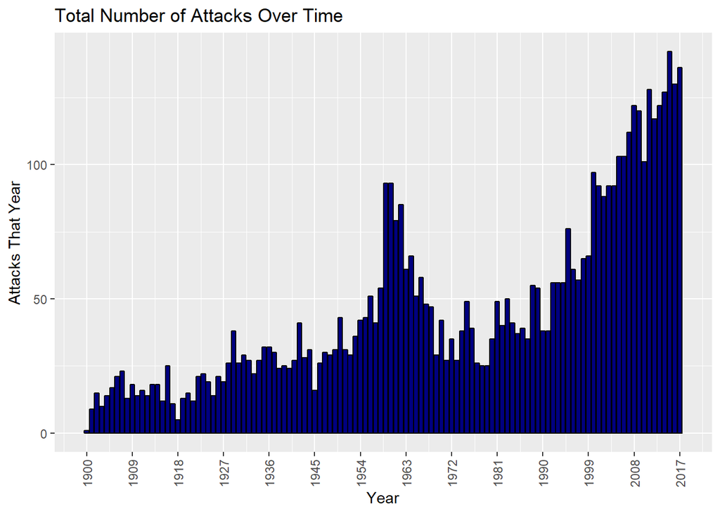

```r
attacksPerYear <- shark_data %>%
  group_by(Year) %>%
  summarize(numOfAttacks = n()) %>%
  ggplot(aes(x=Year, y=numOfAttacks)) + geom_bar(stat = "identity", color = "black", fill = "navyblue") +
    labs(title = "Total Number of Attacks Over Time", x = "Year", y = "Attacks That Year") +
  theme(axis.text.x = element_text(angle = 90, vjust = 0.5)) + scale_x_continuous(breaks=seq(1900, 2017, 9))

attacksPerYear
```

3. One country more than another? We first question this increase by asking, is there one country that is increasing faster/more than any of the other countries? We notice below that these are the top 6 countries that have impacted the total number of shark attacks throughout the years. We see this graph by first grouping our data and counting the number of rows that a certain country has. This determines the total number of attacks that a country has. In order to add the plot we used the geom_bar function, as well as, the geom_text function to label each of the bars with the total number they are. You can read about those functions here: https://ggplot2.tidyverse.org/reference/geom_bar.html and here: https://ggplot2.tidyverse.org/reference/geom_text.html.

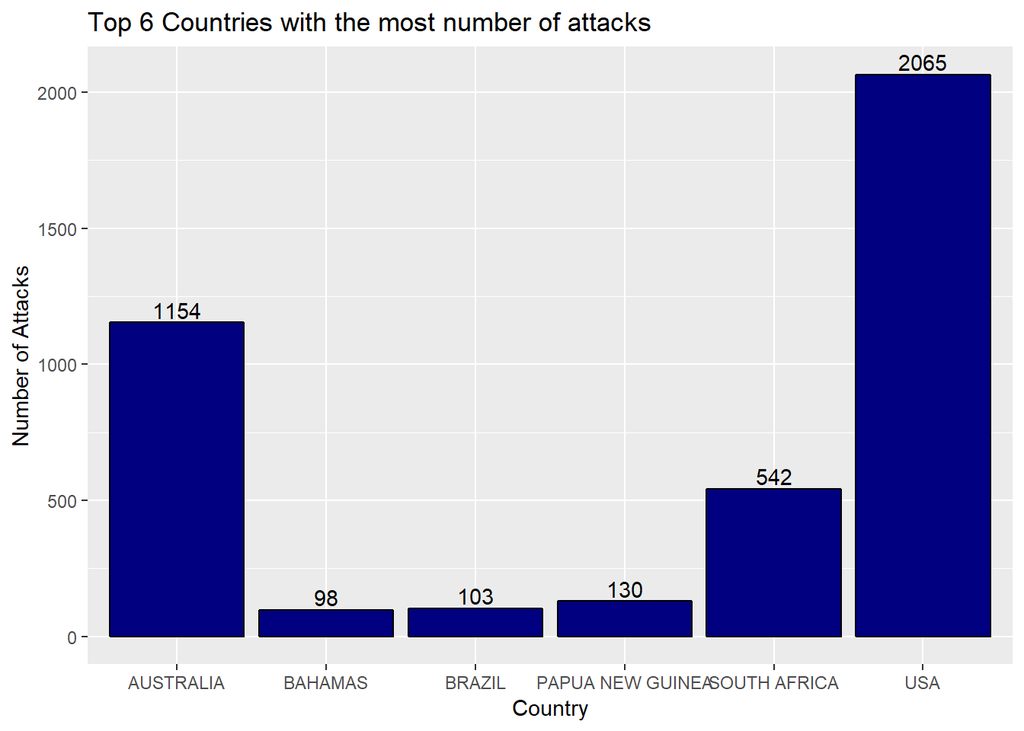

```r
countryTotals <- shark_data %>%
  group_by(Country) %>%
  summarize(attacksForCountries = n()) %>%
  arrange(desc(attacksForCountries))%>%
  head() %>%
  ggplot(aes(x=Country, y=attacksForCountries)) + geom_bar(stat = "identity", color = "black", fill = "navyblue") + labs(title = "Top 6 Countries with the most number of attacks", x = "Country", y = "Number of Attacks") + geom_text(aes(label=attacksForCountries), position=position_dodge(width=0.9), vjust=-0.25)


countryTotals
```

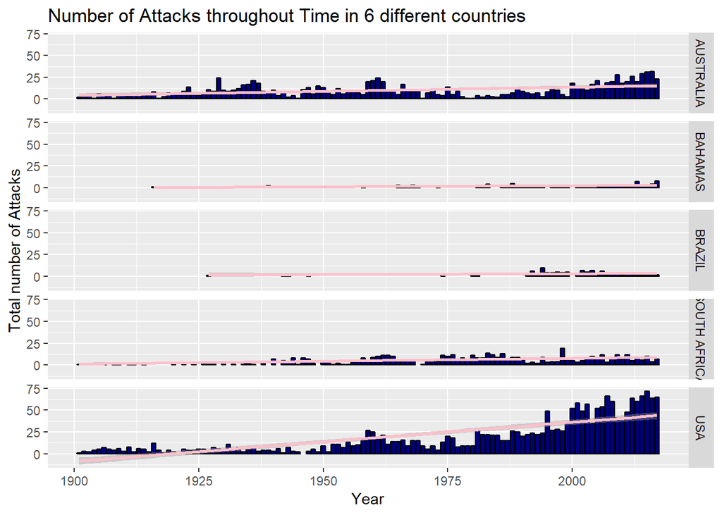

```r
countryThroughTime<- shark_data %>%
  group_by(Year, Country) %>%
  filter(Country == "USA" | Country == "AUSTRALIA" | Country == "SOUTH AFRICA" | Country == "BRAZIL" | Country == "PAPA NEW GUINEA" | Country == "BAHAMAS") %>%
  summarize(attacks = n()) %>%
  ggplot(aes(x=Year, y=attacks)) + geom_bar(stat = "identity", color = "black", fill = "navyblue")+ facet_grid(Country ~ .) + geom_smooth(method = lm, color = "pink") + labs(title = "Number of Attacks throughout Time in 6 different countries", x = "Year", y ="Total number of Attacks")

countryThroughTimeScaled<- shark_data %>%
  group_by(Year, Country) %>%
  filter(Country == "USA" | Country == "AUSTRALIA" | Country == "SOUTH AFRICA" | Country == "BRAZIL" | Country == "PAPA NEW GUINEA" | Country == "BAHAMAS") %>%
  summarize(attacks = n()) %>%
  ggplot(aes(x=Year, y=attacks)) + geom_bar(stat = "identity", color = "black", fill = "navyblue")+ facet_grid(Country ~ ., scales="free") + geom_smooth(method = lm, color = "pink") + labs(title = "Number of Attacks throughout Time in 6 different countries", x = "Year", y ="Total number of Attacks")


countryThroughTime
```

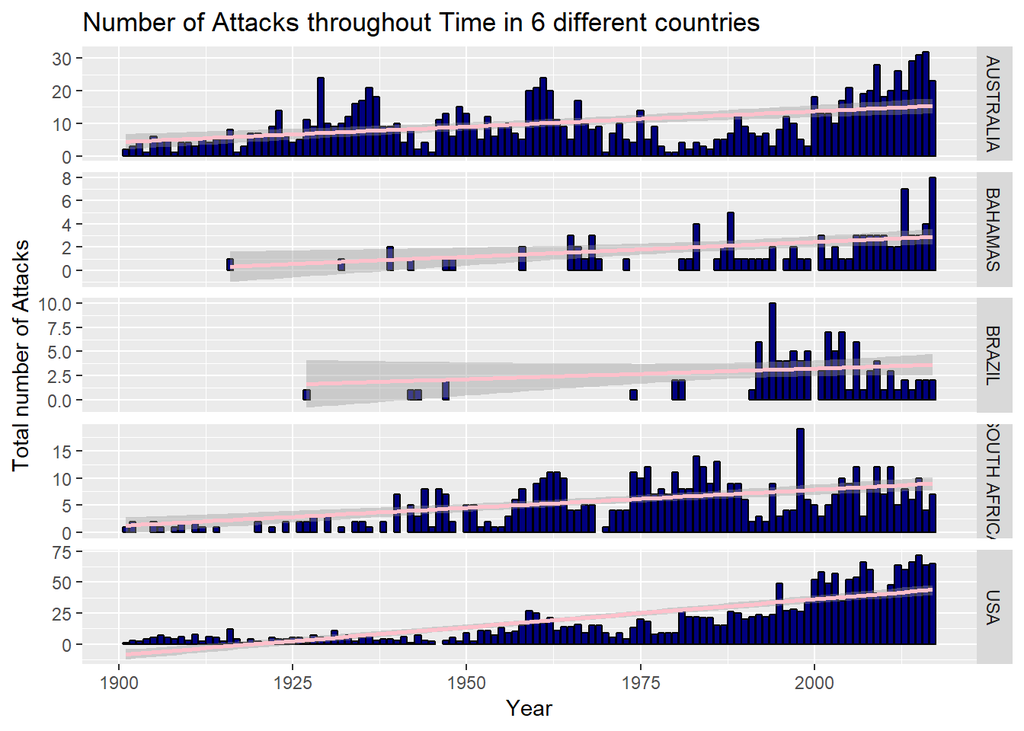

```r
countryThroughTimeScaled
```

4. Analysis on the USA

Let’s see if there is a relationship between time and number of shark attacks for USA. We will do that by fitting a linear regression model to it, and testing if the relationship is statistically significant, we will use the standard alpha value of .05.

```r
usa_data <- shark_data %>%
  filter(Country == "USA") %>%
  group_by(Year) %>%
  summarize(attacks = n())

usa_data
```

```
## # A tibble: 115 x 2
##     Year attacks
##    <dbl>   <int>
##  1  1901       1
##  2  1902       3
##  3  1903       2
##  4  1904       4
##  5  1905       5
##  6  1906       7
##  7  1907       5
##  8  1908       4
##  9  1909       6
## 10  1910       3
## # ... with 105 more rows
```

```r
usa_data_lm <- lm(attacks~Year, data=usa_data)
broom::tidy(usa_data_lm)
```

```
## # A tibble: 2 x 5
##   term        estimate std.error statistic  p.value
##   <chr>          <dbl>     <dbl>     <dbl>    <dbl>
## 1 (Intercept) -864.      59.1        -14.6 8.32e-28
## 2 Year           0.450    0.0301      14.9 1.77e-28
```

Let’s visualize the linear regression by plotting the residuals vs the years.

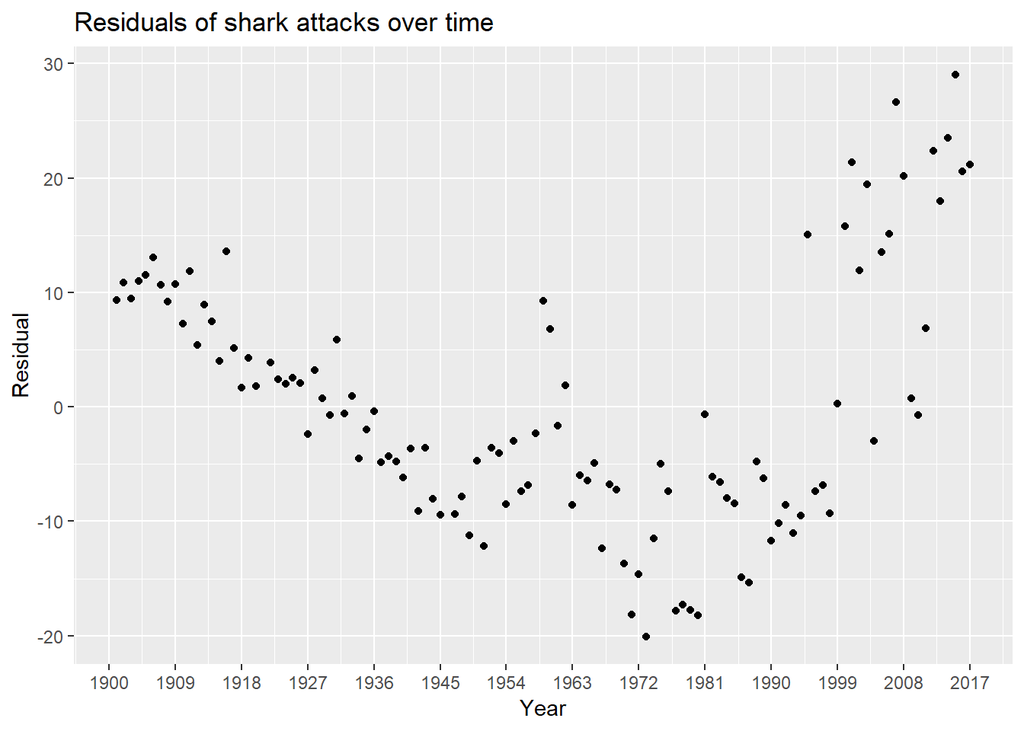

```r
usa_data_lm$Year=as.numeric(levels(usa_data_lm$Year))[usa_data_lm$Year]

broom::augment(usa_data_lm) %>%
  ggplot(aes(x=Year, y = .resid)) +
    geom_point() +
    labs(title = "Residuals of shark attacks over time",
       x = "Year",
       y = "Residual") +
 scale_x_continuous(breaks=seq(1900, 2017, 9))
```

It seems that there is first a decreasing trend before 1970’s which becomes a steeply increasing trend thereafter. Let’s look into what might be causing this trend.

5. Activities effect on Shark Attacks

As we can tell from above, we notice that time does have an impact on the number of attacks that we have in the country. We also noticed that there is a sharp decrease in the residuals which turned into a steep increasing trend after. The cause of this could potentially be based around the type of activities that were popular during these time periods. So, the question we need to ask is, will the type of activity that you are doing cause an effect on the number of attacks? Does activity have a positive correlation to the number of incidents? Seen below is the graph for the top 6 Activities that have caused an attack in the USA. The highest number of attacks is found when someone is surfing in the USA. Let’s dive deeper into the different types of attacks.

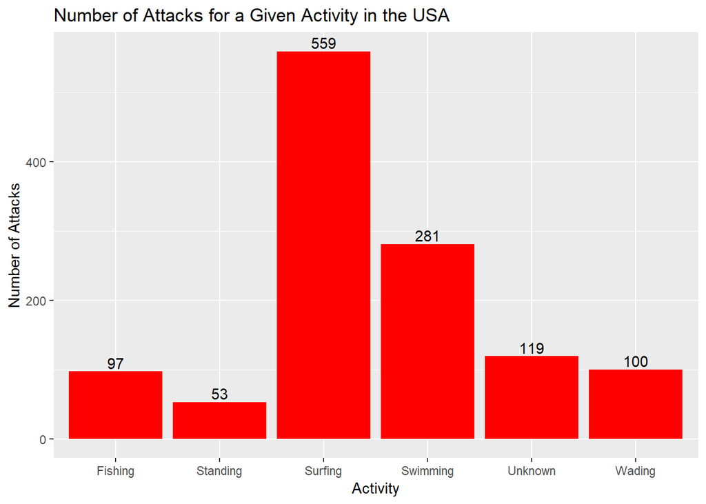

```r
activityAttacks <- shark_data %>%
  group_by(Activity) %>%
  filter(Country =="USA") %>%
  summarize(num = n()) %>%
  arrange(desc(num)) %>%
  mutate(Activity=replace(Activity, is.na(Activity), "Unknown")) %>%
  head() %>%
  ggplot(aes(x = Activity, y = num)) + geom_bar(stat = "identity", fill = "red") + geom_text(aes(label=num), position=position_dodge(width=0.9), vjust=-0.25) + labs(title ="Number of Attacks for a Given Activity in the USA", x = "Activity", y = "Number of Attacks")

activityAttacks
```

Similar to how we calculated the residuals above, we calculated the residuals based on the top 6 activities that we found within the USA. We do this by plotting the residuals just for the USA and then we color those points based on the type of activity that caused that attack. We notice that with this residual plot, as time progresses, the different activities begin to have a lesser impact on the total number of attacks. Also, as time progresses, we begin to see that surfing has become a very large issue in the USA. This makes sense, since our previous bar graph above says that surfing is the number one cause of shark attacks in the USA. So, looking at the residuals we can note that there is a strong relationship between surfing and the shark attacks in the USA.

```r
usa_data <- shark_data %>%
  filter(Country == "USA") %>%
  filter(Activity == "Surfing" | Activity == "Swimming" | Activity == "Unknown" | Activity == "Wading" | Activity == "Fishing" | Activity == "Standing") %>%
  group_by(Year, Activity) %>%
  summarize(attacks = n())

usa_data
```

```
## # A tibble: 280 x 3
## # Groups:   Year [?]
##     Year Activity attacks
##    <dbl> <fct>      <int>
##  1  1902 Fishing        1
##  2  1902 Swimming       1
##  3  1903 Fishing        2
##  4  1904 Swimming       2
##  5  1905 Fishing        1
##  6  1905 Swimming       1
##  7  1905 Wading         1
##  8  1906 Fishing        1
##  9  1906 Swimming       3
## 10  1907 Wading         1
## # ... with 270 more rows
```

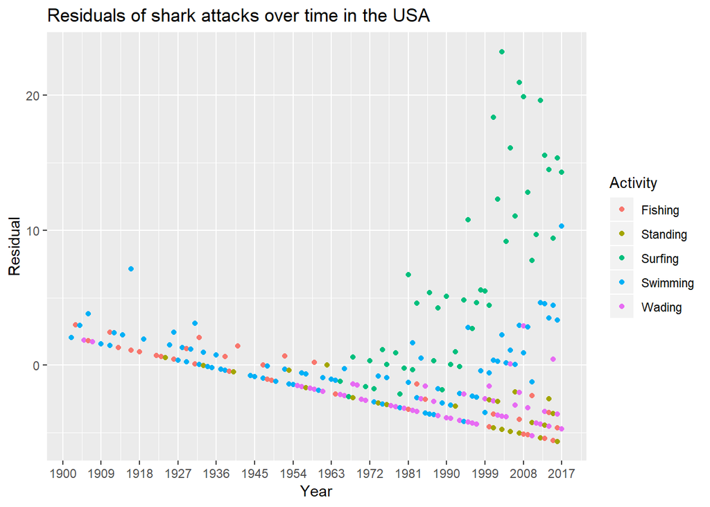

```r
usa_data_lm <- lm(attacks~Year, data=usa_data)

usa_data_lm$Year=as.numeric(levels(usa_data_lm$Year))[usa_data_lm$Year]

broom::augment(usa_data_lm) %>%
  left_join(usa_data, by = c("attacks","Year")) %>%
  ggplot(aes(x=Year, y = .resid, color = Activity)) +
    geom_point() +
    labs(title = "Residuals of shark attacks over time in the USA",
       x = "Year",
       y = "Residual") +
 scale_x_continuous(breaks=seq(1900, 2017, 9))
```

6. Is surfing a huge issue in other countries?

Similar to above, we first found the total number of attacks for a given activity in the world. This helps us see that once again Surfing is a big issue not only in the USA but also in the world. Once again, let’s take a look at the effect that surfing and other activities has on the world throughout time.

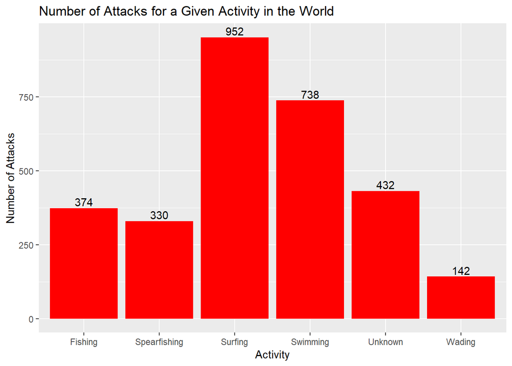

```r
activityAttacksAllCountries <- shark_data %>%
  group_by(Activity) %>%
  summarize(num = n()) %>%
  arrange(desc(num)) %>%
  mutate(Activity=replace(Activity, is.na(Activity), "Unknown")) %>%
  head() %>%
  ggplot(aes(x = Activity, y = num)) + geom_bar(stat = "identity", fill = "red") + geom_text(aes(label=num), position=position_dodge(width=0.9), vjust=-0.25) + labs(title ="Number of Attacks for a Given Activity in the World", x = "Activity", y = "Number of Attacks")
activityAttacksAllCountries
```

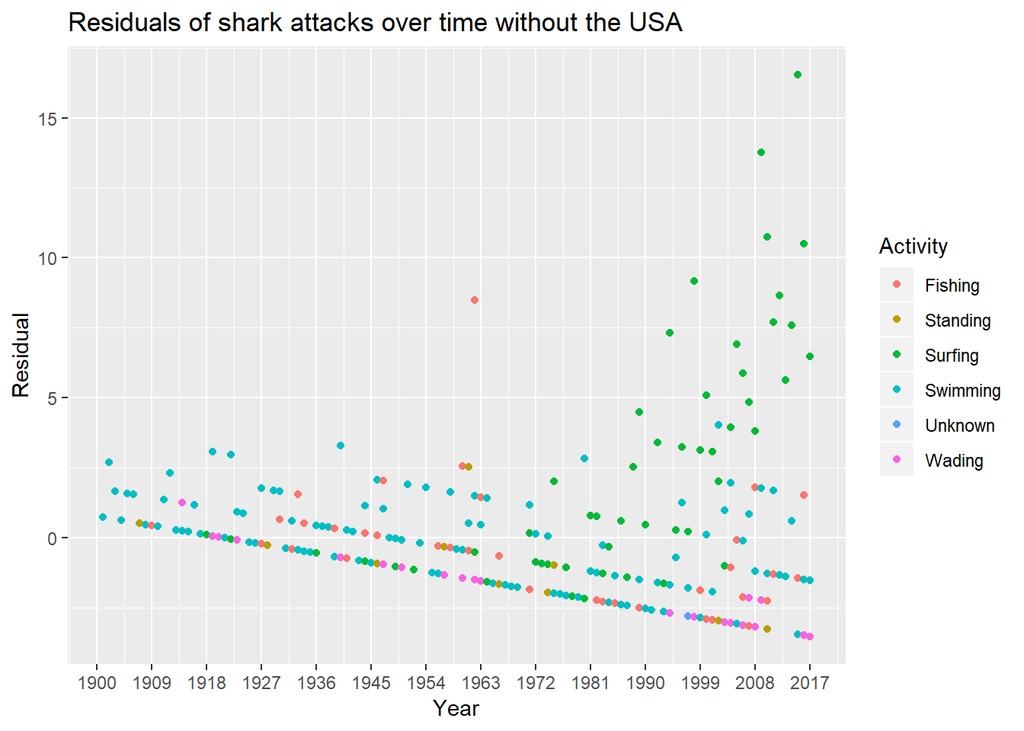

```r
main_countries_no_usa_data <- shark_data %>%
 filter(Country == "AUSTRALIA" | Country == "SOUTH AFRICA" | Country == "BRAZIL" | Country == "NEW ZEALAND" | Country == "BAHAMAS") %>%
  filter(Activity == "Surfing" | Activity == "Swimming" | Activity == "Unknown" | Activity == "Wading" | Activity == "Fishing" | Activity == "Standing") %>%
  group_by(Year, Activity) %>%
  summarize(attacks = n())

main_countries_data <- shark_data %>%
 filter(Country == "USA" | Country == "AUSTRALIA" | Country == "SOUTH AFRICA" | Country == "BRAZIL" | Country == "NEW ZEALAND" | Country == "BAHAMAS") %>%
  filter(Activity == "Surfing" | Activity == "Swimming" | Activity == "Unknown" | Activity == "Wading" | Activity == "Fishing" | Activity == "Standing") %>%
  group_by(Year, Activity) %>%
  summarize(attacks = n())

main_countries_no_usa_data_lm <- lm(attacks~Year, data = main_countries_no_usa_data)
main_countries_no_usa_data_lm$Year = as.numeric(levels(main_countries_no_usa_data_lm$Year))[main_countries_no_usa_data_lm$Year]

broom::augment(main_countries_no_usa_data_lm) %>%
  left_join(main_countries_no_usa_data, by = c("attacks","Year")) %>%
  ggplot(aes(x=Year, y = .resid, color = Activity)) +
    geom_point() +
    labs(title = "Residuals of shark attacks over time without the USA",
       x = "Year",
       y = "Residual") +
 scale_x_continuous(breaks=seq(1900, 2017, 9))
```

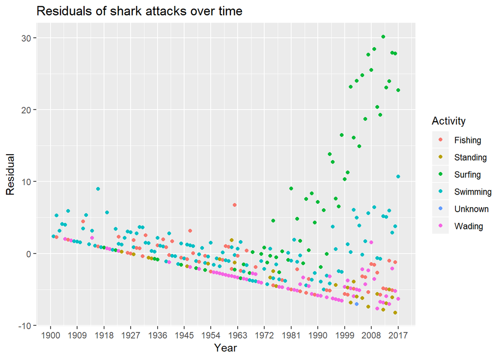

```r
main_countries_data_lm <- lm(attacks~Year, data=main_countries_data)

main_countries_data_lm$Year=as.numeric(levels(main_countries_data_lm$Year))[main_countries_data_lm$Year]

broom::augment(main_countries_data_lm) %>%
  left_join(main_countries_data, by = c("attacks","Year")) %>%
  ggplot(aes(x=Year, y = .resid, color = Activity)) +
    geom_point() +
    labs(title = "Residuals of shark attacks over time",
       x = "Year",
       y = "Residual") +
 scale_x_continuous(breaks=seq(1900, 2017, 9))
```

```r
main_countries_data <- shark_data %>%
 filter(Country == "USA" | Country == "AUSTRALIA" | Country == "SOUTH AFRICA" | Country == "BRAZIL" | Country == "NEW ZEALAND" | Country == "BAHAMAS") %>%
  filter(Activity == "Surfing" | Activity == "Swimming" | Activity == "Unknown" | Activity == "Wading" | Activity == "Fishing" | Activity == "Standing") %>%
  group_by(Year, Activity, Country) %>%
  summarize(attacks = n())

main_countries_data
```

```
## # A tibble: 699 x 4
## # Groups:   Year, Activity [?]
##     Year Activity Country      attacks
##    <dbl> <fct>    <fct>          <int>
##  1  1901 Swimming SOUTH AFRICA       1
##  2  1902 Fishing  USA                1
##  3  1902 Swimming AUSTRALIA          2
##  4  1902 Swimming SOUTH AFRICA       1
##  5  1902 Swimming USA                1
##  6  1903 Fishing  USA                2
##  7  1903 Swimming AUSTRALIA          2
##  8  1904 Swimming NEW ZEALAND        1
##  9  1904 Swimming USA                2
## 10  1905 Fishing  USA                1
## # ... with 689 more rows
```

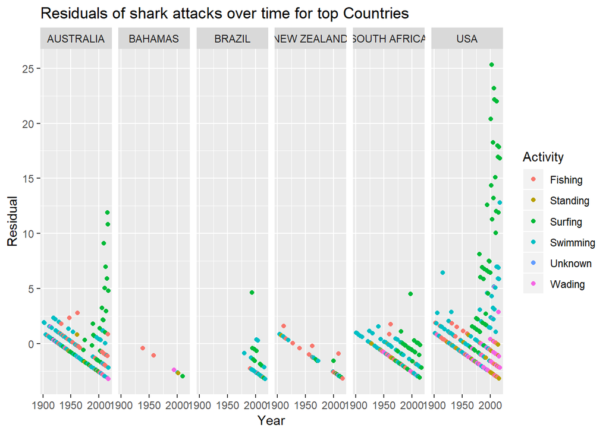

```r
main_countries_data_lm <- lm(attacks~Year, data=main_countries_data)

main_countries_data_lm$Year=as.numeric(levels(main_countries_data_lm$Year))[main_countries_data_lm$Year]

broom::augment(main_countries_data_lm) %>%
  left_join(main_countries_data, by = c("attacks","Year")) %>%
  ggplot(aes(x=Year, y = .resid, color = Activity)) +
    geom_point() +
    labs(title = "Residuals of shark attacks over time for top Countries",
       x = "Year",
       y = "Residual") +
  scale_x_continuous(breaks=seq(1900, 2017, 50)) +
  facet_grid( . ~ Country)
```

Conclusion: Being able to identify which activity has a strong relationship with the number of attacks will be able to help people identify which activities to avoid and be careful of. As noted in the introduction, the article seems to be right with their analysis that sharks are beginning to come closer to the shore. With this increase in sharks at the shore we notice that shark attacks related to shore activities such as surfing and swimming are beginning to increase in a significant rate. We noticed above that time has a strong relationship with the increase in shark attacks, and we also noticed that surfing is also a big cause of shark attacks around the world. So no matter where you go, just remember that you can have fun surfing. But when you’re surfing you need to be aware of the consequences that can come from it.